# Lab 1: Subsetting and exploring data

## Data for today

In addition to data that you can import from a spreadsheet, there are many example datasets that come installed with R and its packages. To see a list of these datasets:

```r
data()
```

Today we’ll explore the `CO2` dataset. We’ll also use the `data` function to load it into our environment.

```r
data(CO2)
```

Since this is an example dataset, it also has a help page.

```r
?CO2
```

Take a moment to view the dataset (by printing the whole thing to the console, or clicking it in the Environment pane). You can also use the `str` function to learn more about it. There is some information printed out by `str` that you might not understand yet, but other information that is useful. What are the column names, and what type of data does each contain? How many observations are there?

Make a new project in RStudio. Create a script file in the main folder that will contain all of your work for today. Create a folder called “data”. Save a copy of the `CO2` data frame to a CSV in that folder (so we can pretend that we’re working with our own data), and add a line to your script to read the data in from CSV. As you work, be sure to add some comments to your script to remind yourself of what is happening.

## Installing and loading a package

We’ll try out two methods for exploring and subsetting our data today. The R “base” has a system that is very flexible. On the other hand, the Tidyverse package `dplyr` has a syntax that is a bit more human readable and easier for beginners. Try them both out and use whichever you prefer (or some combination of the two).

To install `dplyr` (or any other R package), you only need to run `install.packages` once. You might type this command directly into the console, or put it into your script but comment it out so that you don’t accidentally run it again.

```r
install.packages("dplyr")
```

To load a package into your environment, use the `library` function. Generally it is good practice to make all calls to `library` at the very top of your script, so that if you are using the script on another computer, or sharing it with someone else, it is easy to see what packages are required.

```r
library(dplyr)
```

The package name has to be in quotes for `install.packages`, but not for `library`. There isn’t a very good reason for this; it is one of R’s quirks.

To pull up a tutorial on `dplyr`, run

```r
vignette("dplyr")
```

Many packages have “vignette” tutorials in addition to the documentation pages for individual functions. Later in the class when you learn to make your own packages, you will also learn to make vignettes.

## Filtering rows of a data frame

Say we only want to look at the plants from Mississippi. If we run

```r
CO2$Type == "Mississippi"
```

we get a Boolean vector, with `TRUE` for rows from Mississippi and `FALSE` for rows from Quebec. We can use that vector to get a smaller data frame with just those rows.

```r
CO2_Miss <- CO2[CO2$Type == "Mississippi", ]
```

Alternatively, we can use the `filter` function in `dplyr`.

```r
CO2_Miss <- filter(CO2, Type == "Mississippi")
```

Are the results of these two methods different at all? How?

You can filter based on multiple criteria, say only chilled plants from Mississippi. In R base:

```r
CO2_Miss_chilled <- CO2[CO2$Type == "Mississippi" & CO2$Treatment == "chilled", ]
```

In `dplyr`:

```r
CO2_Miss_chilled <- filter(CO2, Type == "Mississippi", Treatment == "chilled")
```

**Question 1 to turn in:** Using your choice of R base or `dplyr`, write a line to filter the `CO2` data frame, returning rows from the chilled treatment where CO2 concentration (`conc`) is above 400.

```r
CO2_chilled_400 <- CO2[CO2$Treatment == "chilled" & CO2$conc > 400, ]

CO2_chilled_400 <- filter(CO2, Treatment == "chilled", conc > 400)

CO2_chilled_400
```

## Sorting a data frame

R has a `sort` function, if you want to sort a single vector:

```r
sort(CO2$uptake)
```

There is also the `order` function, if you want to sort a vector, data frame, or mulitiple vectors based on one or more vectors.

```r
CO2$uptake[order(CO2$conc)]

CO2[order(CO2$uptake),]

CO2[order(CO2$Treatment, CO2$conc),]
```

Here the Treatment column is not sorted alphabetically, but has nonchilled first and chilled second. That is because this column is not being treated as a character vector, but rather is a *factor* that has ordered levels.

```r
CO2$Treatment
```

If we wanted to change the order of the levels:

```r
CO2$Treatment <- factor(CO2$Treatment, levels = c("chilled", "nonchilled"))
```

Now we can sort it differently, with chilled first.

```r
CO2[order(CO2$Treatment, CO2$conc),]
```

In `dplyr`, the `arrange` function is used for sorting.

```r
arrange(CO2, Treatment, conc)
```

## Selecting columns

We’ve already seen the use of `$` to extract individual columns. We can also get a smaller data frame with several columns from the original:

```r
CO2_conc_uptake <- CO2[, c("conc", "uptake")]
```

In `dplyr`, we can do this with `select`:

```r
CO2_conc_uptake <- select(CO2, conc, uptake)
```

## Combining several commands

If we wanted to subset by both rows and columns using R base, we could do so in the same subscript. Remember that row selections go before the comma, and column selections after the comma.

```r
CO2[CO2$Type == "Mississippi" & CO2$Treatment == "chilled", c("conc", "uptake")]
```

In `dplyr`, we could accomplish the same by nesting functions although the code is not very readable:

```r
select(filter(CO2, Type == "Mississippi", Treatment == "chilled"), conc, uptake)
```

Alternatively we can do something in `dplyr` called *piping*. If you have taken a class or workshop on bash programming, you might be familiar with piping as a way to send the output of one program directly to another program as the input. We can do this in `dplyr` too using the `%>%` command, which sends the output of an expression or function to the first argument of the next function. For example:

```r
CO2 %>%
  filter(Type == "Mississippi", Treatment == "chilled") %>%
  select(conc, uptake)
```

**Question 2 to turn in:** Filter the `CO2` data frame to only include plants from Mississippi, and sort the resulting data frame by `conc`. If you are using R base, you can do this in two steps. If using `dplyr`, use piping.

```r
CO2_Miss <- CO2[CO2$Type == "Mississippi",]
CO2_Miss_sort <- CO2_Miss[order(CO2_Miss$conc),]

CO2_Miss_sort <- CO2 %>%
  filter(Type == "Mississippi") %>%
  arrange(conc)

CO2_Miss_sort
```

## Performing operations on subsets of data

Say we wanted the mean uptake for chilled plants from Quebec. We could subset and then take the mean.

```r
mean(CO2$uptake[CO2$Type == "Quebec" & CO2$Treatment == "chilled"])

mean(filter(CO2, Type == "Quebec", Treatment == "chilled")$uptake)
```

But what if we want the mean for each combination of Type and Treatment? It would be tedious to have to type out each one individually. In the R base, there is a very handy function called `tapply` that can separate a vector into groups and then perform some function on each group.

```r
tapply(CO2$uptake, INDEX = list(CO2$Type, CO2$Treatment), FUN = mean)
```

In `dplyr`, we could use `group_by` and `summarize`.

```r
group_by(CO2, Type, Treatment) %>%
  summarize(mean_uptake = mean(uptake))
```

In this example, `mean_uptake` is an arbitrary variable name; I could have called it anything I wanted.

**Question 3 to turn in:** Get the minimum and maximum uptake for each combination of Type, Treatment, and conc. You can do this with R base or `dplyr`, using either one or two commands.

```r
tapply(CO2$uptake, INDEX = list(CO2$Type, CO2$Treatment, CO2$conc), FUN = min)
tapply(CO2$uptake, INDEX = list(CO2$Type, CO2$Treatment, CO2$conc), FUN = max)

group_by(CO2, Type, Treatment, conc) %>%
  summarize(min_uptake = min(uptake), max_uptake = max(uptake))
```

## Adding new columns

Say we wanted the CO2 uptake in micromoles per meter squared per minute instead of per second. We can add new columns using the `$` operator, the same way we access columns.

```r
CO2$uptake_minutes <- CO2$uptake * 60
```

(You might use `head(CO2)` to preview the results.)

In `dplyr` we can accomplish this task with `mutate`.

```r
CO2 <- mutate(CO2, uptake_minutes = uptake * 60)
```

## If you have extra time

Look through the `dplyr` vignette, explore other features, and experiment with other datasets. You may notice that the vignette uses a “tibble” rather than a data frame; take a look at the `tibble` package to learn more. See what happens when you try to use `$` to access a column that doesn’t exist in a data frame vs. in a tibble.

You may also wish to take a look at another Tidyverse package called `ggplot2`. We’ll have a lab on that package later in the course. For example, here is a useful plot of the `CO2` dataset:

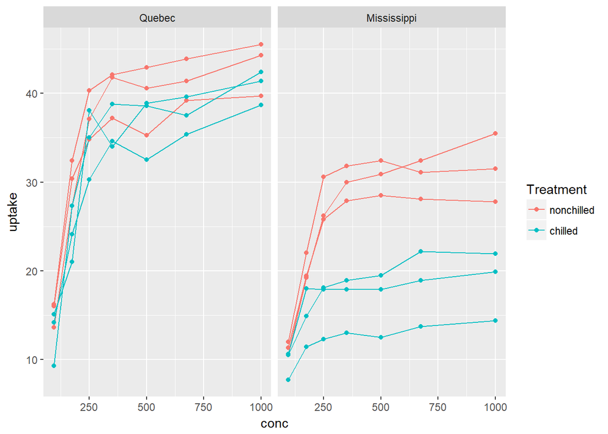

```r
library(ggplot2)

ggplot(CO2, aes(x = conc, y = uptake, color = Treatment)) +
  geom_line(aes(group = Plant)) +
  geom_point() +
  facet_wrap(~ Type)
```